# Introduction to Regression in Machine Learning

## Linear Regression

Linear Regression tries to find the line of best fit which best represents the relationship between an independent variable ($x$) and a dependent variable ($y$):  
$y = ax + b$

Where:

- $a$ is the slope of the line
- $b$ is the intercept

The objective is to minimise the errors between the predicted values by the model and the actual observed values.

👉 Here is a visual interaction to better our understanding of how the line of best fit is found: [Dynamic Visualisation](https://setosa.io/ev/ordinary-least-squares-regression/)

## Linear Regression in `sklearn`

There are two ways to navigate the `sklearn` documentation:

- [User Guide](https://scikit-learn.org/stable/user_guide.html): Explanation of the concepts covered in the package and the underlying math. Great to discover new tools for preprocessing our data and better our understanding of models.
- [API](https://scikit-learn.org/stable/api/index.html): How to interact with the package in our code

For this example we will use the California Housing Dataset from `sklearn`.  
You can find more information on this dataset [here](https://scikit-learn.org/stable/datasets/real_world.html#california-housing-dataset).

### Data Import

```python
from sklearn.datasets import fetch_california_housing
import pandas as pd

X, y = fetch_california_housing(as_frame = True, return_X_y= True)
X.head()
```

|  | MedInc | HouseAge | AveRooms | AveBedrms | Population | AveOccup | Latitude | Longitude |
| --- | --- | --- | --- | --- | --- | --- | --- | --- |
| 0 | 8.3252 | 41.0 | 6.984127 | 1.023810 | 322.0 | 2.555556 | 37.88 | -122.23 |
| 1 | 8.3014 | 21.0 | 6.238137 | 0.971880 | 2401.0 | 2.109842 | 37.86 | -122.22 |
| 2 | 7.2574 | 52.0 | 8.288136 | 1.073446 | 496.0 | 2.802260 | 37.85 | -122.24 |
| 3 | 5.6431 | 52.0 | 5.817352 | 1.073059 | 558.0 | 2.547945 | 37.85 | -122.25 |
| 4 | 3.8462 | 52.0 | 6.281853 | 1.081081 | 565.0 | 2.181467 | 37.85 | -122.25 |

Feature and target information:

- `MedHouseValue`: this is the target, the variable we are trying to predict. It represents the median house value per California block group
- `MedInc`: this is the median income per California block group
- `HouseAge`: this is the median house age per California block group
- `AveRooms`: this is the average number of rooms per household
- `AveBedrms`: this is the average number of bedrooms per household
- `Population`: this is the population per California block group
- `AveOccup`: this is the average number of household members
- `Latitude`: California block group latitude
- `Longitude`: California block group longitude

Since we have `longitude` and `latitude` we can see the `MedHouseValue` on a map of California

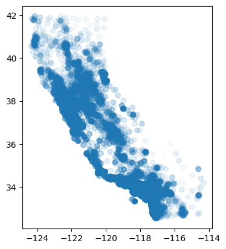

```python
import pandas as pd
import geopandas
import matplotlib.pyplot as plt

map_df = pd.concat([X[['Latitude', 'Longitude']],y], axis = 1)
map_geodf = geopandas.GeoDataFrame(
    map_df, geometry=geopandas.points_from_xy(map_df.Longitude, map_df.Latitude), crs="EPSG:4326"
)

# To show the Median income values for each block district we can
# normalise y since it has to be between 0 and 1
alpha_values = (y - y.min()) / (y.max() - y.min())

map_geodf.plot(alpha=alpha_values)
plt.show()
```

## Data Cleaning

```python
X.info()
```

```
<class 'pandas.core.frame.DataFrame'>
RangeIndex: 20640 entries, 0 to 20639
Data columns (total 8 columns):
 #   Column      Non-Null Count  Dtype
---  ------      --------------  -----
 0   MedInc      20640 non-null  float64
 1   HouseAge    20640 non-null  float64
 2   AveRooms    20640 non-null  float64
 3   AveBedrms   20640 non-null  float64
 4   Population  20640 non-null  float64
 5   AveOccup    20640 non-null  float64
 6   Latitude    20640 non-null  float64
 7   Longitude   20640 non-null  float64
dtypes: float64(8)
memory usage: 1.3 MB
```

There are no missing values so lets continue with the analysis

### Data Preprocessing

As we only have numeric values, we will simply scale them before training our model. There are a lot of preprocessing and feature engineering steps we could take here. But for now let's keep things simple.

```python
from sklearn.preprocessing import RobustScaler

r_scaler = RobustScaler().set_output(transform = "pandas")
X_scaled = r_scaler.fit_transform(X)
```

### Training a `LinearRegression`

```python
# Import model
from sklearn.linear_model import LinearRegression

# Instanciate model
model = LinearRegression()

# Train model
model.fit(X_scaled,y)
```

```
LinearRegression()
```

We now have a fitted model 🚀  
We could run predictions on it, but we have no idea of its performance. This is where model evaluation becomes crucial.

## How to cross validate our models

### `train_test_split` method (also called Hold Out Method)

```python
from sklearn.model_selection import train_test_split


# Split our X and y into train and test sets
X_train, X_test, y_train, y_test = train_test_split(X_scaled, y, test_size = 0.3)

# Instanciate the model
model = LinearRegression()

# Train the model on the train set
model.fit(X_train, y_train)

# Evaluate the model on the test set
model.score(X_test, y_test)
```

```
0.6164003629409898
```

By default the score used for `model.score()` in a regression task is the $R^2$, this score is not very representative.  
Let us use the Root Mean Squared Error (RMSE) instead. This metric represents the standard deviation of the residuals and penalises more heavily bigger mistakes.

```python
from sklearn.metrics import root_mean_squared_error

score = root_mean_squared_error(y_true = y_test, y_pred = model.predict(X_test))
score
```

```
0.7078921818394874
```

```python
score * 100000
```

```
70789.21818394875
```

⚠️ This `train_test_split` method is not robust enough. We want to have an idea of the performance of our model when it has seen all of the data

### `K Fold Cross Validation`

```python
from sklearn.model_selection import cross_val_score

cross_val_score(LinearRegression(), X_scaled, y, cv = 5, scoring="neg_root_mean_squared_error").mean()
```

```
-0.745906836351811
```

A hypothetical `LinearRegression`, trained on all of the data. Would have a RMSE equal to 0.74590 or 74,590 USD.

## Improving the score ?

There a few strategies we could put in place to improve the score:

- paying more attention to the preprocessing steps: using different scalers
- using the latitude and longitude features to engineer new features, knowing that California is on the coast maybe we could include that
- using a more powerful model

Thanks to our `LinearRegression` we have now set a baseline or a score to beat on our next iteration